# 📖 Taller 1 (Solución usando SageMath)

## Teoría de Grafos

### Alejandra Torres Manotas

📍 **PUNTO 1:** Haga un grafo isomorfo al siguiente grafo

```python
g=Graph()
g.add_vertices(["$v_1$","$v_2$","$v_3$","$v_4$","$v_5$"])
g.add_edges([("$v_1$","$v_3$","d"),("$v_1$","$v_4$","i"),("$v_1$","$v_5$","a")])
g.add_edges([("$v_2$","$v_3$","c"),("$v_2$","$v_4$","b"),("$v_2$","$v_5$","h")])
g.add_edges([("$v_4$","$v_3$","f"),("$v_5$","$v_3$","e")])
g.add_edges([("$v_4$","$v_5$","g")])
```

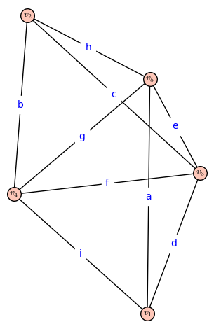

```python
g.graphplot(edge_labels=True).plot()
```

**Solución:**

Para generar un grafo isomorfo al anteriormente presentado se determinará una permutación en los vértices. En otras palabras, si consideramos que son 5 vértices tomaremos un elemento del conjunto de permutaciones de $\{1,2,3,4,5\}$:

```python
SymmetricGroup(5)[5]
```

```
(2,5,4,3)
```

Esta permutación define la siguiente función:

- A $v_1$ le asigna $v_1$,
- A $v_2$ le asigna $v_5$,
- A $v_3$ le asigna $v_2$,
- A $v_4$ le asigna $v_3$,
- A $v_5$ le asigna $v_4$.

```python
g2=Graph()
g2.add_vertices(["$v_1$","$v_2$","$v_3$","$v_4$","$v_5$"])
g2.add_edges([("$v_1$","$v_2$","d"),("$v_1$","$v_3$","i"),("$v_1$","$v_4$","a")])
g2.add_edges([("$v_5$","$v_2$","c"),("$v_5$","$v_3$","b"),("$v_5$","$v_4$","h")])
g2.add_edges([("$v_3$","$v_2$","f"),("$v_4$","$v_2$","e")])
g2.add_edges([("$v_3$","$v_4$","g")])
```

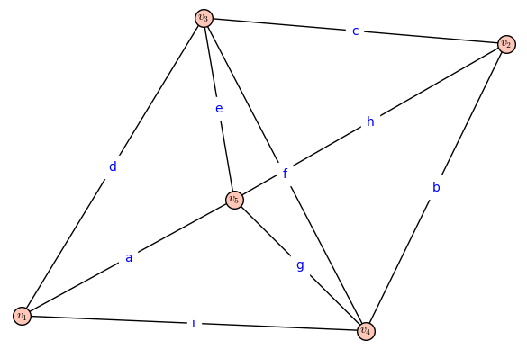

```python
g.graphplot(edge_labels=True).plot()
```

🔎 Veamos esto por qué es verdad usando matrices de adyacencia. Primero determinemos la matriz de permutación dada por $(2,5,4,3)$:

```python
mp=SymmetricGroup(5)[5].matrix() #Matriz de permutación de este elemento
mp
```

```
[1 0 0 0 0]
[0 0 0 0 1]
[0 1 0 0 0]
[0 0 1 0 0]
[0 0 0 1 0]
```

Ahora, dos grafos son isomorfos si existe dicha permutación o existe una matriz de permutaciones tal que las matrices de adyacencia, de los grafos que estoy comparando, sean semesjantes. Entonces, con la definición de semejanza hallaremos la matriz del grafo isomorfo al presentado al comienzo: $$ mp\times mg = mg \times mp.$$

```python
#Matriz de adyacencia del grafo g (Dado en el punto 1)
mg=Matrix(g)
mg
```

```
[0 0 1 1 1]
[0 0 1 1 1]
[1 1 0 1 1]
[1 1 1 0 1]
[1 1 1 1 0]
```

```python
#Matriz del grafo isomorfo g2
mgi=(mp^-1)*mg*mp
mgi
```

```
[0 1 1 1 0]
[1 0 1 1 1]
[1 1 0 1 1]
[1 1 1 0 1]
[0 1 1 1 0]
```

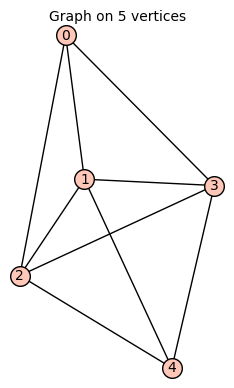

```python
#Dibujo de g2
gi=Graph(mgi)
gi
```

Que es el mismo grafo presentado como solución.

📍 **PUNTO 2:** Diga si los siguientes grafos son isomorfos

[figure not shown]

**Solución:** Son isomorfos.

El grafo de la izquierda es de Petersen entonces se usará la función *graphs.PetersenGraph()* y para el segundo grafo usaremos el siguiente etiquetado en los vértices:

[figure not shown]

Ahora, para cada caso se generará la matriz de adyacencia y se verificará si existe una matriz de permutación de 10 elementos tal que las dos matrices de adyacencia sean semejantes. Esto con el objetivo de determinar la función que representa al isomorfismo.

```python
p=graphs.PetersenGraph()
mpt=matrix(p)
mpt
```

```
[0 1 0 0 1 1 0 0 0 0]
[1 0 1 0 0 0 1 0 0 0]
[0 1 0 1 0 0 0 1 0 0]
[0 0 1 0 1 0 0 0 1 0]
[1 0 0 1 0 0 0 0 0 1]
[1 0 0 0 0 0 0 1 1 0]
[0 1 0 0 0 0 0 0 1 1]
[0 0 1 0 0 1 0 0 0 1]
[0 0 0 1 0 1 1 0 0 0]
[0 0 0 0 1 0 1 1 0 0]
```

```python
g3=Graph()
g3.add_vertices([0,1,2,3,4,5,6,7,8,9])
g3.add_edges([(0,1),(1,2),(2,3),(3,4),(4,5),(5,0),(0,6),(6,9),(2,7),(7,9),(4,8),(8,9),(5,7),(1,8),(3,6)])
mg3=matrix(g3)
mg3
```

```
[0 1 0 0 0 1 1 0 0 0]
[1 0 1 0 0 0 0 0 1 0]
[0 1 0 1 0 0 0 1 0 0]
[0 0 1 0 1 0 1 0 0 0]
[0 0 0 1 0 1 0 0 1 0]
[1 0 0 0 1 0 0 1 0 0]
[1 0 0 1 0 0 0 0 0 1]
[0 0 1 0 0 1 0 0 0 1]
[0 1 0 0 1 0 0 0 0 1]
[0 0 0 0 0 0 1 1 1 0]
```

```python
# Test rápido de SageMath para isomorfismo
p.is_isomorphic(g3)
```

```
True
```

```python
#Mostrar que las matrices de adyacencia son semejantes
for s in SymmetricGroup(10):
    S = s.matrix() #Matriz de permutación
    if mpt*S == S*mg3:
        print(s)
        break
```

```
(1,2,9,7,10,8,6)(3,5)
```

Considerando que el etiquetado de los vértices va de $0-9$ y no de $1-10$, entonces la permutación es $(0,1,8,6,9,7,5)(2,4)$. Finalmente, la función $f$ entre los vértices del grafo $p$ y el grafo $g_3$, que determina el isomorfismo, es:

- $f(0)=1$,
- $f(1)=8$,
- $f(2)=4$,
- $f(3)=3$,
- $f(4)=2$,
- $f(5)=0$,
- $f(6)=9$,
- $f(7)=5$,
- $f(8)=6$,
- $f(9)=7$.

📍 **PUNTO 3:** Del siguiente grafo:

```python
g4=Graph(loops=True,multiedges=True)
g4.add_vertices(["$v_1$","$v_2$","$v_3$","$v_4$"])
g4.add_edges([("$v_1$","$v_2$","$e_1$"),("$v_1$","$v_2$","$e_2$"),("$v_1$","$v_3$","$e_7$"),("$v_3$","$v_2$","$e_3$")])
g4.add_edges([("$v_1$","$v_4$","$e_5$"),("$v_3$","$v_4$","$e_4$"),("$v_4$","$v_4$","$e_6$")])
```

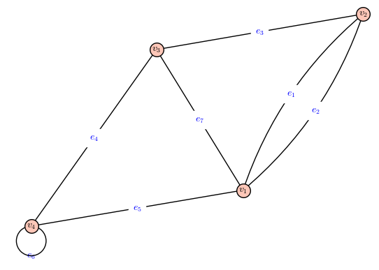

```python
g4.graphplot(edge_labels=True).plot()
```

**a.** Muestre 2 ejemplos de grafo recubridor.

**b.** Muestre 2 ejemplos de grafo inducido.

**Solución:**

```python
#Ejemplo 1: Grafo recubridor

g5=Graph(multiedges=True)
g5.add_vertices(["$v_1$","$v_2$","$v_3$","$v_4$"])
g5.add_edges([("$v_3$","$v_2$","$e_3$")])
g5.add_edges([("$v_1$","$v_4$","$e_5$"),("$v_3$","$v_4$","$e_4$")])
```

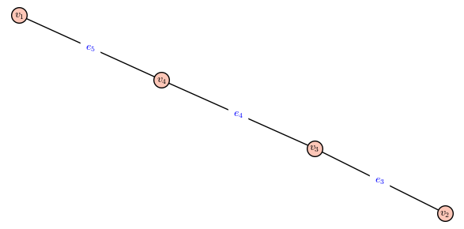

```python
g5.graphplot(edge_labels=True).plot()
```

```python
#Ejemplo 2: Grafo recubridor

g6=Graph(multiedges=True)
g6.add_vertices(["$v_1$","$v_2$","$v_3$","$v_4$"])
g6.add_edges([("$v_3$","$v_2$","$e_3$")])
g6.add_edges([("$v_1$","$v_4$","$e_5$"),("$v_1$","$v_3$","$e_7$"),("$v_3$","$v_4$","$e_4$")])
```

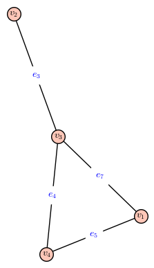

```python
g6.graphplot(edge_labels=True).plot()
```

```python
# Ejemplo 1: Grafo inducido

g7=Graph(multiedges=True)
g7.add_vertices(["$v_1$","$v_2$","$v_3$"])
g7.add_edges([("$v_1$","$v_2$","$e_1$"),("$v_1$","$v_2$","$e_2$"),("$v_1$","$v_3$","$e_7$"),("$v_3$","$v_2$","$e_3$")])
```

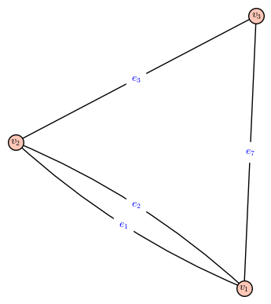

```python
g7.graphplot(edge_labels=True).plot()
```

```python
# Elemplo 2: Grafo inducido

g8=Graph(loops=True,multiedges=True)
g8.add_vertices(["$v_3$","$v_4$"])
g8.add_edges([("$v_3$","$v_4$","$e_4$"),("$v_4$","$v_4$","$e_6$")])
```

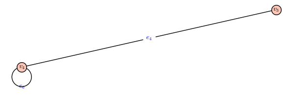

```python
g8.graphplot(edge_labels=True).plot()
```

📍 **PUNTOS EN GOOGLE COLAB** [Enlace](https://colab.research.google.com/drive/1KbEkuJCCwNaDJ3AjoEn55dASMeb673rP?usp=sharing)